# LBB Regression

Francis Yeh

18 Mar 2020

# 1 Introduction

## 1.1 Background

The cancer dataset consists of 34 columns and 3047 observations:

## 1.2 Overview of Variables

- Cancer data from Data:
  - `avgAnnCount`: The average number of new cancer cases per year per county for years 2009-2013
  - `popEst2015`: Estimated population by county
  - `incidenceRate`: Mean per capita (100,000) cancer diagnoses
  - `studyPerCap`: Per capita number of cancer-related clinical trials per county
- Economic status:
  - `medIncome`: Median income per county
  - `povertyPercent`: Percent of population below poverty line
  - `binnedInc`: County-level income distributed in bins
- Population age and gender:
  - `MedianAge`: Median age per county
  - `MedianAgeMale`: Median age among males per county
  - `MedianAgeFemale`: Median age among females per county
- Location:
  - `Geography`: County, State names
- Marital status:
  - `PercentMarried`: Percentage of married population
  - `PctMarriedHouseholds`: Percentage of married households per county
- Education:
  - `PctNoHS18_24`: Percentage of 18-24 year old population with no high school education
  - `PctHS18_24`: Percentage of 18-24 year old population with high school education
  - `PctSomeCol18_24`: Percentage of 18-24 year old population with some college education
  - `PctBachDeg18_24`: Percentage of 18-24 year old population with bachelor’s degree
  - `PctHS25_Over`: Percentage of population above 25 years old with high school education
  - `PctBachDeg25_Over`: Percentage of population above 25 years old with bachelor’s degree
- Household size:
  - `AvgHouseholdSize`: Average household size per county
- Employment status:
  - `PctEmployed16_Over`: Percentage of population above 16 years old who have jobs
  - `PctUnemployed16_Over`: Percentage of population above 16 years old with no jobs
- Health insurance coverage:
  - `PctPrivateCoverage`: Percentage of the population with private insurance coverage
  - `PctEmpPrivCoverage`: percentage of the population with employer-sponsored insurance coverage
  - `PctPublicCoverage`: Percentage of the population with public insurance coverage
- Race:
  - `PctWhite`: Percentage of white population by county
  - `PctBlack`: Percentage of African-American population by county
  - `PctAsian`: Percentage of Asian population by county
  - `PctOtherRace`: Percentage of other races by county
- Birth and death rates:
  - `BirthRate`: Birth rate per county
  - `avgDeathsPerYear`: Death rate per county

## 1.3 Libraries and Setup

To run the data preparation and the statistical analysis, the following libraries are loaded

# 2 Exploratory Data Analysis

## 2.1 Data Table

```
##   avgAnnCount      avgDeathsPerYear TARGET_deathRate incidenceRate
##  Min.   :    6.0   Min.   :    3    Min.   : 59.7    Min.   : 201.3
##  1st Qu.:   76.0   1st Qu.:   28    1st Qu.:161.2    1st Qu.: 420.3
##  Median :  171.0   Median :   61    Median :178.1    Median : 453.5
##  Mean   :  606.3   Mean   :  186    Mean   :178.7    Mean   : 448.3
##  3rd Qu.:  518.0   3rd Qu.:  149    3rd Qu.:195.2    3rd Qu.: 480.9
##  Max.   :38150.0   Max.   :14010    Max.   :362.8    Max.   :1206.9
##
##    medIncome        popEst2015       povertyPercent   studyPerCap
##  Min.   : 22640   Min.   :     827   Min.   : 3.20   Min.   :   0.00
##  1st Qu.: 38883   1st Qu.:   11684   1st Qu.:12.15   1st Qu.:   0.00
##  Median : 45207   Median :   26643   Median :15.90   Median :   0.00
##  Mean   : 47063   Mean   :  102637   Mean   :16.88   Mean   : 155.40
##  3rd Qu.: 52492   3rd Qu.:   68671   3rd Qu.:20.40   3rd Qu.:  83.65
##  Max.   :125635   Max.   :10170292   Max.   :47.40   Max.   :9762.31
##
##               binnedInc      MedianAge      MedianAgeMale   MedianAgeFemale
##  (45201, 48021.6]  : 306   Min.   : 22.30   Min.   :22.40   Min.   :22.30
##  (54545.6, 61494.5]: 306   1st Qu.: 37.70   1st Qu.:36.35   1st Qu.:39.10
##  [22640, 34218.1]  : 306   Median : 41.00   Median :39.60   Median :42.40
##  (42724.4, 45201]  : 305   Mean   : 45.27   Mean   :39.57   Mean   :42.15
##  (48021.6, 51046.4]: 305   3rd Qu.: 44.00   3rd Qu.:42.50   3rd Qu.:45.30
##  (51046.4, 54545.6]: 305   Max.   :624.00   Max.   :64.70   Max.   :65.70
##  (Other)           :1214
##                             Geography    AvgHouseholdSize PercentMarried
##  Abbeville County, South Carolina:   1   Min.   :0.0221   Min.   :23.10
##  Acadia Parish, Louisiana        :   1   1st Qu.:2.3700   1st Qu.:47.75
##  Accomack County, Virginia       :   1   Median :2.5000   Median :52.40
##  Ada County, Idaho               :   1   Mean   :2.4797   Mean   :51.77
##  Adair County, Iowa              :   1   3rd Qu.:2.6300   3rd Qu.:56.40
##  Adair County, Kentucky          :   1   Max.   :3.9700   Max.   :72.50
##  (Other)                         :3041
##   PctNoHS18_24     PctHS18_24   PctSomeCol18_24 PctBachDeg18_24
##  Min.   : 0.00   Min.   : 0.0   Min.   : 7.10   Min.   : 0.000
##  1st Qu.:12.80   1st Qu.:29.2   1st Qu.:34.00   1st Qu.: 3.100
##  Median :17.10   Median :34.7   Median :40.40   Median : 5.400
##  Mean   :18.22   Mean   :35.0   Mean   :40.98   Mean   : 6.158
##  3rd Qu.:22.70   3rd Qu.:40.7   3rd Qu.:46.40   3rd Qu.: 8.200
##  Max.   :64.10   Max.   :72.5   Max.   :79.00   Max.   :51.800
##                                 NA's   :2285
```

[output cut: 17 more lines]

```
##  Min.   :11.20     Min.   : 2.60          Min.   : 10.20   Min.   : 0.0000
##  1st Qu.:30.90     1st Qu.:14.85          1st Qu.: 77.30   1st Qu.: 0.6207
##  Median :36.30     Median :18.80          Median : 90.06   Median : 2.2476
##  Mean   :36.25     Mean   :19.24          Mean   : 83.65   Mean   : 9.1080
##  3rd Qu.:41.55     3rd Qu.:23.10          3rd Qu.: 95.45   3rd Qu.:10.5097
##  Max.   :65.10     Max.   :46.60          Max.   :100.00   Max.   :85.9478
##
##     PctAsian        PctOtherRace     PctMarriedHouseholds   BirthRate
##  Min.   : 0.0000   Min.   : 0.0000   Min.   :22.99        Min.   : 0.000
##  1st Qu.: 0.2542   1st Qu.: 0.2952   1st Qu.:47.76        1st Qu.: 4.521
##  Median : 0.5498   Median : 0.8262   Median :51.67        Median : 5.381
##  Mean   : 1.2540   Mean   : 1.9835   Mean   :51.24        Mean   : 5.640
##  3rd Qu.: 1.2210   3rd Qu.: 2.1780   3rd Qu.:55.40        3rd Qu.: 6.494
##  Max.   :42.6194   Max.   :41.9303   Max.   :78.08        Max.   :21.326
##
```

```
##      avgAnnCount avgDeathsPerYear TARGET_deathRate incidenceRate medIncome
## 3042    1962.668               48            146.4      453.5494     49508
## 3043    1962.668               15            149.6      453.5494     46961
## 3044    1962.668               43            150.1      453.5494     48609
## 3045    1962.668               46            153.9      453.5494     51144
## 3046    1962.668               52            175.0      453.5494     50745
## 3047    1962.668               48            213.6      453.5494     41193
##      popEst2015 povertyPercent studyPerCap          binnedInc MedianAge
## 3042      29029           13.0    723.4145 (48021.6, 51046.4]      32.2
## 3043       6343           12.4      0.0000   (45201, 48021.6]      44.2
## 3044      37118           18.8    377.1755 (48021.6, 51046.4]      30.4
## 3045      34536           15.0   1968.9599 (51046.4, 54545.6]      30.9
## 3046      25609           13.3      0.0000 (48021.6, 51046.4]      39.0
## 3047      37030           13.9      0.0000 (40362.7, 42724.4]      26.2
##      MedianAgeMale MedianAgeFemale                Geography AvgHouseholdSize
```

[output cut: 41 more lines]

## 2.2 Check for Missing Values & Incorrect Data

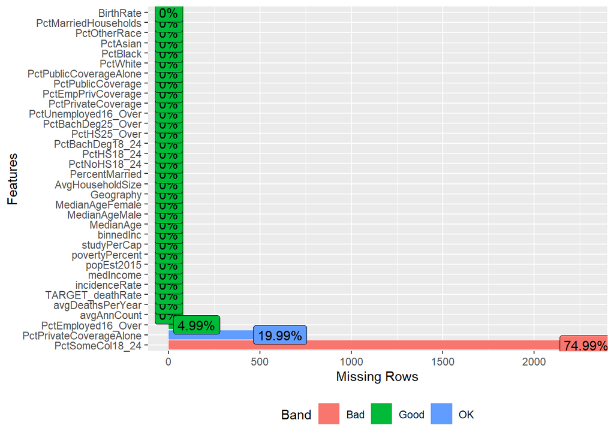

```r
plot_missing(df)
```

There are 2285, 152, 609 missing values for variables`PctSomeCol18_24`, `PctEmployed16_Over` and `PctPrivateCoverageAlone` respectively.

In addition, the max value(624) for variable `MedianAge` and min value(0.0221) for variable `AvgHouseholdSize` does not make sense which require further examination.

There are erroneous `AvgHouseholdSize` with values less than 1.

30 observations with `MedianAge of above 100.

Interestingly, there are observations for Kansas, Nevada, Minnesota counties with similar values, namely `avgAnnCount` of 1962.667684 and corresponding `incidenceRate` of 453.5494.

I will also remove the variable `studyPerCap`as it contains 0 values to avoid computing issues for correlation analysis.

## 2.3 Impute Missing and Incorrect values

Impute erroneous median age >100 and update with average of MedianAgeMale and MedianAgeFemale

Impute incorrect AvgHouseholdSize < 1

Impute PctSomeCol18_24 by subtracting the other educational variables 18_24 from 100

Remove observations with incorrect avgAnnCount value of 1962.667684

Remove variables avgAnnCount, avgDeathsPerYear, binnedInc and Geography

```r
df$MedianAge100 = 0 #create a new column to save the dubious data
df$MedianAge100[df$MedianAge>100]<- df$MedianAge[df$MedianAge>100]
df[df$MedianAge>100,c("Geography","MedianAge","MedianAgeMale", "MedianAgeFemale","MedianAge100") ] #show Age data before update
```

```
##                                Geography MedianAge MedianAgeMale
## 101              Seward County, Nebraska     458.4          36.3
## 182          Sandoval County, New Mexico     469.2          37.6
## 226        Pittsylvania County, Virginia     546.0          44.2
## 319               Iosco County, Michigan     624.0          51.6
## 426        Person County, North Carolina     508.8          41.5
## 607              Mineral County, Montana     619.2          52.3
## 638                Cass County, Nebraska     498.0          40.4
## 844         Tangipahoa Parish, Louisiana     412.8          33.0
## 992              Greene County, Virginia     481.2          39.4
## 1200        Harrison County, Mississippi     424.8          34.2
## 1313                 Lane County, Kansas     535.2          44.7
## 1407               Weld County, Colorado     406.8          33.3
## 1580                 Lake County, Oregon     579.6          48.2
## 1726         Greene County, Pennsylvania     502.8          40.7
```

[output cut: 47 more lines]

```r
df$MedianAge[df$MedianAge>100]<- (df$MedianAgeMale[df$MedianAge>100] + df$MedianAgeFemale[df$MedianAge>100])/2  #update the Median Age
df[df$MedianAge100>100,c("Geography","MedianAge","MedianAgeMale", "MedianAgeFemale","MedianAge100") ] # Check data
```

```
##                                Geography MedianAge MedianAgeMale
## 101              Seward County, Nebraska     38.50          36.3
## 182          Sandoval County, New Mexico     38.85          37.6
## 226        Pittsylvania County, Virginia     45.45          44.2
## 319               Iosco County, Michigan     52.05          51.6
## 426        Person County, North Carolina     42.45          41.5
## 607              Mineral County, Montana     51.50          52.3
## 638                Cass County, Nebraska     41.40          40.4
## 844         Tangipahoa Parish, Louisiana     34.30          33.0
## 992              Greene County, Virginia     40.40          39.4
## 1200        Harrison County, Mississippi     35.50          34.2
## 1313                 Lane County, Kansas     44.55          44.7
## 1407               Weld County, Colorado     33.85          33.3
## 1580                 Lake County, Oregon     48.35          48.2
## 1726         Greene County, Pennsylvania     42.10          40.7
```

[output cut: 47 more lines]

```r
df$AvgHouseholdSize1 = 0 #create a new column to perform manipulation for AvgHouseholdsize<1
df$AvgHouseholdSize1[df$AvgHouseholdSize<1]<- df$AvgHouseholdSize[df$AvgHouseholdSize<1]
df$AvgHouseholdSize[df$AvgHouseholdSize<1]<- df$AvgHouseholdSize[df$AvgHouseholdSize<1]*100
df$PctTotal18_24 = 100  #create to derive missing values for PctSomeCol18_24
df$PctSomeCol18_24 <- df$PctTotal18_24 - df$PctNoHS18_24 - df$PctHS18_24 - df$PctBachDeg18_24


dfM <- df %>%
        filter(!grepl('1962.667684', avgAnnCount)) # removing observations
dfP <- dfM[,c(3:7,10:12,14:34)]  #removing non-numeric variables such as #`binnedInc` and `Geography`  to perform correlation between #independent variables
dfP <- dfP [, -31]
## write.csv(dfP, "C:\\Users\\joshr\\Documents\\cancer_medianAge.csv",row.names=TRUE)
```

Impute missing values for variables `PctEmployed16_Over` and `PctPrivateCoverageAlone` using mean.

```r
df_replace <-data.frame(
    sapply(
        dfP,
        function(x) ifelse(is.na(x),
            mean(x, na.rm = TRUE),
            x)))
## write.csv(df_replace, "C:\\Users\\joshr\\Documents\\cancer_PartA.csv", row.names=TRUE)
```

## 2.4 Check for any more missing value

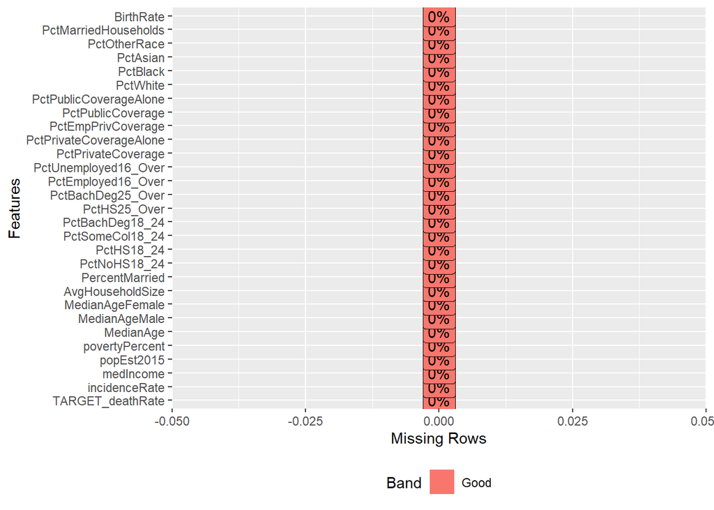

```r
plot_missing(df_replace)
```

## 2.5 Check for correlation between columns

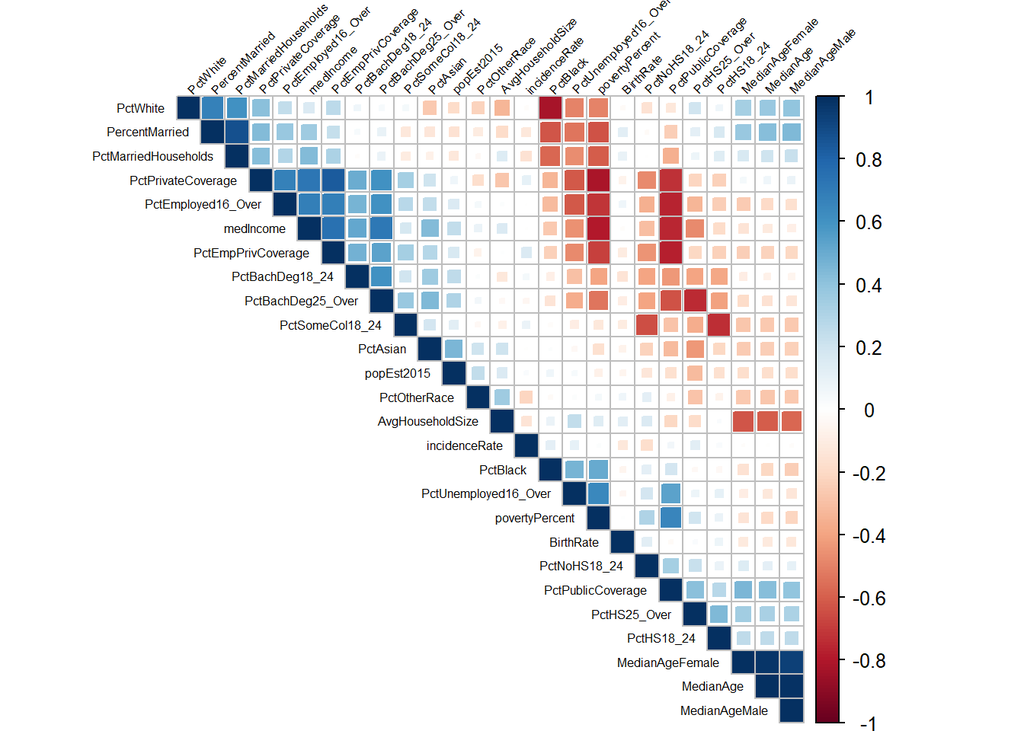

```r
cr <- cor(df_replace[, c("incidenceRate","popEst2015", "BirthRate", "MedianAge", "MedianAgeMale", "MedianAgeFemale",
"PctWhite", "PctBlack", "PctAsian", "PctOtherRace", "AvgHouseholdSize", "PercentMarried",
"PctMarriedHouseholds", "PctNoHS18_24", "PctHS18_24", "PctHS25_Over", "PctSomeCol18_24",
"PctBachDeg18_24", "PctBachDeg25_Over", "PctPrivateCoverage", "PctEmpPrivCoverage",
"PctPublicCoverage", "PctEmployed16_Over", "PctUnemployed16_Over", "medIncome",
"povertyPercent")], use = "complete.obs")
corrplot(corr = cr, type = "upper", tl.col = "black", tl.cex = 0.5, tl.srt = 45,
method = "square", order = "AOE")
```

### 2.5.1 Display correlation against Dependent Variable

```r
x <- names(df_replace)[!names(df_replace) %in% c("TARGET_deathRate", "X")]
vars <- c()
cors <- c()
for (i in x) {
if (class(df_replace[, i]) == "numeric") {
vars <- c(vars, i)
1
cors <- c(cors, round(cor(df_replace[, i], df_replace$TARGET_deathRate, use = "complete.obs"), digits = 4))
}
}
cor_df <- data.frame(vars, cors, row.names = NULL)
cor_df <- cor_df[order(abs(cor_df$cors), decreasing = T), ]
kable(cor_df, col.names = c("Variable", "Correlation Coefficient"), row.names = F,
caption = "Correlation Coefficients of Independent Variables to TARGET Death Rate (Part A)")
```

Correlation Coefficients of Independent Variables to TARGET Death Rate (Part A)

| Variable | Correlation Coefficient |
| --- | --- |
| PctBachDeg25_Over | -0.4906 |
| incidenceRate | 0.4692 |
| PctPublicCoverageAlone | 0.4448 |
| medIncome | -0.4267 |
| povertyPercent | 0.4204 |
| PctHS25_Over | 0.4105 |
| PctPublicCoverage | 0.4040 |
| PctEmployed16_Over | -0.3868 |
| PctPrivateCoverage | -0.3699 |
| PctUnemployed16_Over | 0.3638 |
| PctPrivateCoverageAlone | -0.3138 |
| PctBachDeg18_24 | -0.2865 |
| PctMarriedHouseholds | -0.2819 |
| PctEmpPrivCoverage | -0.2534 |
| PercentMarried | -0.2518 |
| PctBlack | 0.2501 |
| PctHS18_24 | 0.2491 |
| PctOtherRace | -0.2091 |
| PctAsian | -0.1964 |
| PctWhite | -0.1630 |
| PctSomeCol18_24 | -0.1578 |
| popEst2015 | -0.1304 |
| PctNoHS18_24 | 0.0954 |
| BirthRate | -0.0710 |
| AvgHouseholdSize | -0.0566 |
| MedianAgeMale | -0.0198 |
| MedianAgeFemale | 0.0169 |
| MedianAge | -0.0016 |

The correlation coefficients ranges from -0.4906 and 0.4692, with medium to low correlation between the variables.

## 2.6 Check for data skewness

```r
skewness(df_replace$TARGET_deathRate)
```

```
## [1] 0.2185482
```

```r
skewness(df_replace$PctPublicCoverageAlone)
```

```
## [1] 0.4314025
```

```r
skewness(df_replace$povertyPercent)
```

```
## [1] 0.8775318
```

```r
skewness(df_replace$AvgHouseholdSize)
```

```
## [1] 1.330844
```

```r
skewness(df_replace$PctUnemployed16_Over)
```

```
## [1] 0.888652
```

```r
skewness(df_replace$PctBlack)
```

```
## [1] 2.151763
```

```r
skewness(df_replace$PctHS18_24)
```

```
## [1] 0.1875554
```

# 3 Regression Model

After addressing the missing values, I run my first linear regression model named model_allVarA and achieved the adjusted R-squared: 0.5258 with Residual standard error: 19.1 on 2813 degrees of freedom

```r
model_allVarA <- lm(TARGET_deathRate ~. -PctBachDeg18_24, data=df_replace)
summary(model_allVarA)
```

```
##
## Call:
## lm(formula = TARGET_deathRate ~ . - PctBachDeg18_24, data = df_replace)
##
## Residuals:
##      Min       1Q   Median       3Q      Max
## -102.029  -10.623   -0.499   10.587  136.843
##
## Coefficients:
##                           Estimate Std. Error t value Pr(>|t|)
## (Intercept)              1.995e+02  2.283e+01   8.737  < 2e-16 ***
## incidenceRate            1.895e-01  7.158e-03  26.474  < 2e-16 ***
## medIncome                1.604e-04  8.253e-05   1.944 0.051998 .
## popEst2015              -1.474e-06  1.266e-06  -1.164 0.244438
## povertyPercent           2.546e-01  1.615e-01   1.576 0.115044
## MedianAge                1.360e+00  1.130e+00   1.204 0.228676
## MedianAgeMale           -1.154e+00  6.484e-01  -1.780 0.075112 .
## MedianAgeFemale         -9.715e-01  5.750e-01  -1.690 0.091221 .
## AvgHouseholdSize        -1.151e+01  3.274e+00  -3.517 0.000444 ***
## PercentMarried           8.226e-01  1.964e-01   4.189 2.88e-05 ***
## PctNoHS18_24            -5.559e-02  1.189e-01  -0.467 0.640217
## PctHS18_24               2.641e-01  1.134e-01   2.329 0.019933 *
## PctSomeCol18_24          4.168e-02  1.134e-01   0.368 0.713237
## PctHS25_Over             3.753e-01  9.858e-02   3.807 0.000144 ***
## PctBachDeg25_Over       -1.282e+00  1.595e-01  -8.040 1.31e-15 ***
## PctEmployed16_Over      -4.709e-01  1.057e-01  -4.454 8.74e-06 ***
## PctUnemployed16_Over     2.251e-01  1.714e-01   1.314 0.189052
## PctPrivateCoverage      -6.431e-01  1.461e-01  -4.401 1.12e-05 ***
## PctPrivateCoverageAlone  7.235e-02  8.715e-02   0.830 0.406515
## PctEmpPrivCoverage       3.995e-01  1.076e-01   3.711 0.000210 ***
## PctPublicCoverage       -2.294e-01  2.344e-01  -0.979 0.327676
## PctPublicCoverageAlone   4.164e-01  2.868e-01   1.452 0.146611
## PctWhite                -1.687e-01  5.921e-02  -2.849 0.004412 **
## PctBlack                -7.002e-02  5.627e-02  -1.244 0.213535
## PctAsian                -1.109e-01  1.886e-01  -0.588 0.556626
## PctOtherRace            -9.611e-01  1.269e-01  -7.576 4.82e-14 ***
## PctMarriedHouseholds    -7.583e-01  2.047e-01  -3.705 0.000216 ***
## BirthRate               -7.861e-01  1.994e-01  -3.943 8.26e-05 ***
## ---
## Signif. codes:  0 '***' 0.001 '**' 0.01 '*' 0.05 '.' 0.1 ' ' 1
##
## Residual standard error: 19.1 on 2813 degrees of freedom
## Multiple R-squared:  0.5303, Adjusted R-squared:  0.5258
## F-statistic: 117.6 on 27 and 2813 DF,  p-value: < 2.2e-16
```

## 3.1 Diagnostic Plots for Model

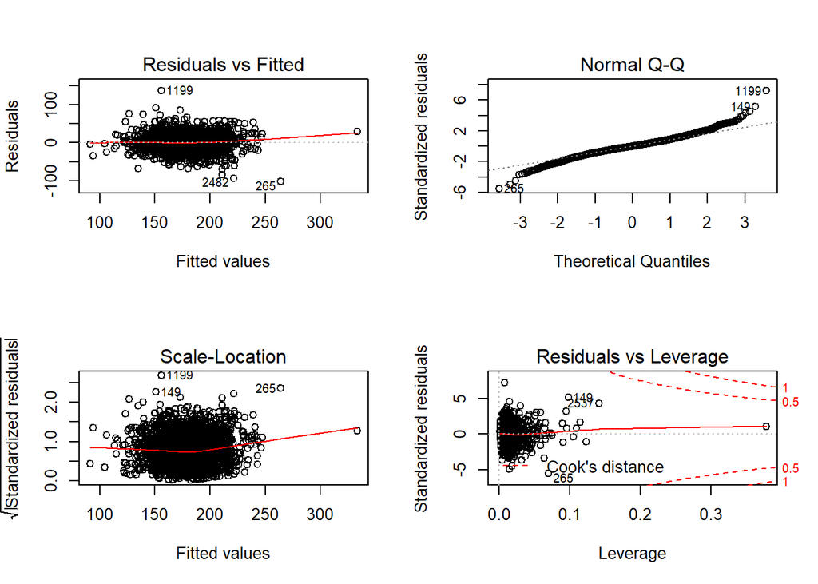

```r
par(mfrow=c(2,2))
plot(model_allVarA,1)
plot(model_allVarA,2)
plot(model_allVarA,3)
plot(model_allVarA,5)
```

```r
## stats::step(model_allVarA,direction="both")
```

# 4 Improve Regression Model

Add the variable Geography back to dataframe

Add the interaction effects using variable State and Incidence Rate

```r
dfM <- dfM %>% separate(Geography, c("County", "State"), sep = ", ", remove = FALSE)
str(dfM)
```

```
## 'data.frame':    2841 obs. of  39 variables:
##  $ avgAnnCount            : num  1397 173 102 427 57 ...
##  $ avgDeathsPerYear       : int  469 70 50 202 26 152 97 71 36 1380 ...
##  $ TARGET_deathRate       : num  165 161 175 195 144 ...
##  $ incidenceRate          : num  490 412 350 430 350 ...
##  $ medIncome              : int  61898 48127 49348 44243 49955 52313 37782 40189 42579 60397 ...
##  $ popEst2015             : int  260131 43269 21026 75882 10321 61023 41516 20848 13088 843954 ...
##  $ povertyPercent         : num  11.2 18.6 14.6 17.1 12.5 15.6 23.2 17.8 22.3 13.1 ...
##  $ studyPerCap            : num  499.7 23.1 47.6 342.6 0 ...
##  $ binnedInc              : Factor w/ 10 levels "(34218.1, 37413.8]",..: 9 6 6 4 6 7 2 2 3 8 ...
##  $ MedianAge              : num  39.3 33 45 42.8 48.3 45.4 42.6 51.7 49.3 35.8 ...
##  $ MedianAgeMale          : num  36.9 32.2 44 42.2 47.8 43.5 42.2 50.8 48.4 34.7 ...
##  $ MedianAgeFemale        : num  41.7 33.7 45.8 43.4 48.9 48 43.5 52.5 49.8 37 ...
##  $ Geography              : Factor w/ 3047 levels "Abbeville County, South Carolina",..: 1459 1460 1464 1589 1618 1766 2051 2112 2143 2185 ...
##  $ County                 : chr  "Kitsap County" "Kittitas County" "Klickitat County" "Lewis County" ...
```

[output cut: 25 more lines]

```r
df_replace <- cbind(df_replace,State=dfM$State)
```

Adding interaction effects

```r
model_allVarB <- lm(TARGET_deathRate ~. -PctBachDeg18_24 + State*incidenceRate, data=df_replace)
summary(model_allVarB)
```

```
##
## Call:
## lm(formula = TARGET_deathRate ~ . - PctBachDeg18_24 + State *
##     incidenceRate, data = df_replace)
##
## Residuals:
##     Min      1Q  Median      3Q     Max
## -82.088  -9.575  -0.373   9.566 124.854
##
## Coefficients: (1 not defined because of singularities)
##                                           Estimate Std. Error t value Pr(>|t|)
## (Intercept)                              1.593e+02  4.066e+01   3.919 9.13e-05
## incidenceRate                            1.436e-01  7.383e-02   1.945  0.05188
## medIncome                                9.237e-05  8.576e-05   1.077  0.28156
## popEst2015                              -1.260e-06  1.232e-06  -1.023  0.30654
## povertyPercent                           2.308e-01  1.621e-01   1.424  0.15457
## MedianAge                                8.045e-01  1.062e+00   0.757  0.44892
## MedianAgeMale                           -7.508e-01  6.110e-01  -1.229  0.21921
## MedianAgeFemale                         -5.414e-01  5.444e-01  -0.994  0.32013
## AvgHouseholdSize                        -5.207e+00  3.267e+00  -1.594  0.11107
## PercentMarried                           4.703e-01  1.993e-01   2.360  0.01837
## PctNoHS18_24                             1.923e-01  1.174e-01   1.639  0.10137
## PctHS18_24                               2.956e-01  1.115e-01   2.651  0.00808
## PctSomeCol18_24                          1.435e-01  1.098e-01   1.307  0.19136
## PctHS25_Over                             1.553e-01  1.151e-01   1.349  0.17744
## PctBachDeg25_Over                       -1.103e+00  1.718e-01  -6.418 1.62e-10
## PctEmployed16_Over                      -2.431e-01  1.111e-01  -2.188  0.02875
## PctUnemployed16_Over                     3.151e-01  1.786e-01   1.765  0.07768
## PctPrivateCoverage                      -8.087e-02  1.614e-01  -0.501  0.61643
## PctPrivateCoverageAlone                  1.201e-01  8.124e-02   1.479  0.13937
## PctEmpPrivCoverage                       6.105e-02  1.121e-01   0.545  0.58601
## PctPublicCoverage                       -4.596e-02  2.438e-01  -0.189  0.85049
## PctPublicCoverageAlone                   5.845e-01  2.958e-01   1.976  0.04829
## PctWhite                                -1.691e-01  6.824e-02  -2.477  0.01329
## PctBlack                                -1.319e-01  7.235e-02  -1.823  0.06844
## PctAsian                                -2.921e-03  2.215e-01  -0.013  0.98948
## PctOtherRace                            -6.102e-01  1.321e-01  -4.620 4.01e-06
## PctMarriedHouseholds                    -6.746e-01  1.981e-01  -3.405  0.00067
## BirthRate                               -5.106e-01  1.900e-01  -2.687  0.00726
## StateAlaska                              2.874e+01  4.225e+01   0.680  0.49634
```

[output cut: 207 more lines]

```
## incidenceRate:StateTennessee
## incidenceRate:StateTexas
## incidenceRate:StateUtah
## incidenceRate:StateVermont
## incidenceRate:StateVirginia
## incidenceRate:StateWashington
## incidenceRate:StateWest Virginia
## incidenceRate:StateWisconsin
## incidenceRate:StateWyoming
## ---
## Signif. codes:  0 '***' 0.001 '**' 0.01 '*' 0.05 '.' 0.1 ' ' 1
##
## Residual standard error: 17.5 on 2720 degrees of freedom
## Multiple R-squared:  0.6185, Adjusted R-squared:  0.6017
## F-statistic: 36.75 on 120 and 2720 DF,  p-value: < 2.2e-16
```

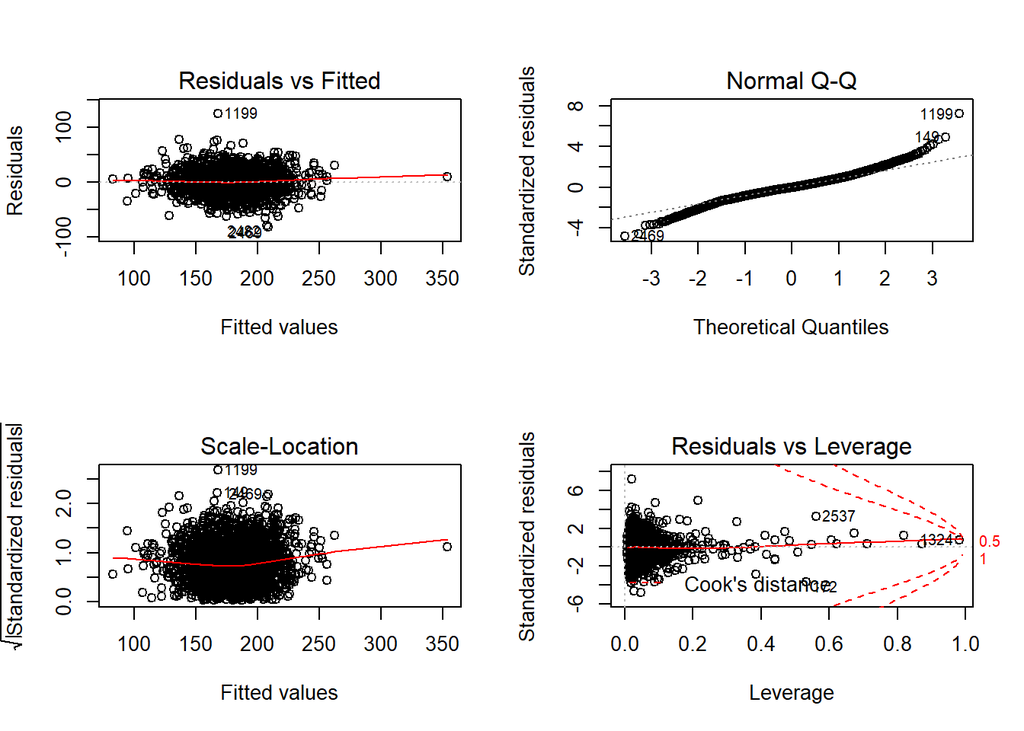

```r
par(mfrow=c(2,2))
plot(model_allVarB,1)
plot(model_allVarB,2)
plot(model_allVarB,3)
plot(model_allVarB,5)
```

```r
stats::step(model_allVarB,direction="both")
```

```
## Start:  AIC=16382.59
## TARGET_deathRate ~ (incidenceRate + medIncome + popEst2015 +
##     povertyPercent + MedianAge + MedianAgeMale + MedianAgeFemale +
##     AvgHouseholdSize + PercentMarried + PctNoHS18_24 + PctHS18_24 +
##     PctSomeCol18_24 + PctBachDeg18_24 + PctHS25_Over + PctBachDeg25_Over +
##     PctEmployed16_Over + PctUnemployed16_Over + PctPrivateCoverage +
##     PctPrivateCoverageAlone + PctEmpPrivCoverage + PctPublicCoverage +
##     PctPublicCoverageAlone + PctWhite + PctBlack + PctAsian +
##     PctOtherRace + PctMarriedHouseholds + BirthRate + State) -
##     PctBachDeg18_24 + State * incidenceRate
##
##                           Df Sum of Sq    RSS   AIC
## - PctAsian                 1         0 833357 16381
## - PctPublicCoverage        1        11 833368 16381
## - PctPrivateCoverage       1        77 833434 16381
## - PctEmpPrivCoverage       1        91 833448 16381
## - MedianAge                1       176 833532 16381
## - MedianAgeFemale          1       303 833660 16382
## - popEst2015               1       320 833677 16382
## - medIncome                1       355 833712 16382
## - MedianAgeMale            1       463 833819 16382
## - PctSomeCol18_24          1       523 833880 16382
## - PctHS25_Over             1       558 833914 16382
## <none>                                 833357 16383
## - povertyPercent           1       621 833978 16383
## - PctPrivateCoverageAlone  1       670 834026 16383
## - AvgHouseholdSize         1       778 834135 16383
## - PctNoHS18_24             1       823 834180 16383
## - PctUnemployed16_Over     1       954 834311 16384
## - PctBlack                 1      1018 834375 16384
## - PctPublicCoverageAlone   1      1196 834553 16385
## - PctEmployed16_Over       1      1467 834824 16386
## - PercentMarried           1      1706 835063 16386
## - PctWhite                 1      1880 835237 16387
## - PctHS18_24               1      2153 835509 16388
## - BirthRate                1      2212 835568 16388
## - PctMarriedHouseholds     1      3553 836910 16393
## - PctOtherRace             1      6540 839897 16403
## - PctBachDeg25_Over        1     12621 845978 16423
## - incidenceRate:State     46     40413 873769 16425
```

[output cut: 482 more lines]

```
## + PctAsian                 1        40 837123 16371
## + MedianAge                1        24 837138 16372
## + medIncome                1        21 837141 16372
## + PctSomeCol18_24          1        18 837145 16372
## - PctWhite                 1      2107 839269 16375
## - BirthRate                1      2314 839476 16375
## - PctEmployed16_Over       1      3357 840519 16379
## - PercentMarried           1      3432 840595 16379
## - PctHS18_24               1      3807 840969 16380
## - MedianAgeMale            1      4850 842012 16384
## - PctPublicCoverageAlone   1      7148 844311 16392
## - PctOtherRace             1      8065 845227 16395
## - PctMarriedHouseholds     1     10098 847260 16402
## - incidenceRate:State     46     41580 878742 16415
## - PctBachDeg25_Over        1     44005 881167 16513
```

```
##
## Call:
## lm(formula = TARGET_deathRate ~ incidenceRate + MedianAgeMale +
##     PercentMarried + PctHS18_24 + PctBachDeg25_Over + PctEmployed16_Over +
##     PctUnemployed16_Over + PctPrivateCoverageAlone + PctPublicCoverageAlone +
##     PctWhite + PctBlack + PctOtherRace + PctMarriedHouseholds +
##     BirthRate + State + incidenceRate:State, data = df_replace)
##
## Coefficients:
##                             (Intercept)
##                               1.708e+02
##                           incidenceRate
##                               1.441e-01
##                           MedianAgeMale
##                              -4.368e-01
##                          PercentMarried
##                               5.429e-01
##                              PctHS18_24
##                               1.599e-01
##                       PctBachDeg25_Over
##                              -1.280e+00
##                      PctEmployed16_Over
##                              -2.823e-01
##                    PctUnemployed16_Over
##                               2.852e-01
##                 PctPrivateCoverageAlone
##                               1.318e-01
##                  PctPublicCoverageAlone
##                               6.119e-01
##                                PctWhite
##                              -1.575e-01
##                                PctBlack
##                              -1.078e-01
##                            PctOtherRace
##                              -6.613e-01
##                    PctMarriedHouseholds
##                              -7.862e-01
##                               BirthRate
##                              -5.184e-01
##                             StateAlaska
```

[output cut: 172 more lines]

```
##                               1.043e-01
##                 incidenceRate:StateUtah
##                               2.832e-02
##              incidenceRate:StateVermont
##                               1.227e-01
##             incidenceRate:StateVirginia
##                              -9.134e-02
##           incidenceRate:StateWashington
##                               2.318e-03
##        incidenceRate:StateWest Virginia
##                               6.954e-02
##            incidenceRate:StateWisconsin
##                              -8.165e-02
##              incidenceRate:StateWyoming
##                               8.049e-02
```